# Lab #3 Power and sample size

### Calculate the pooled variance

```r
# Load the packages
library(pwr)
```

```r
# size of each group
nx <- length(x)
ny <- length(y)
# Calculate the pooled variance as coded in the lecture notes
pool.var <- (((nx-1)*var(x)) + ((ny-1)*var(y)))/(nx+ny-2)
pool.var
```

```
## [1] 0.3320136
```

### Calculate the minimum sample size necessary to detect a 1.5 fold difference (at 80% power and 99% confidence)

```r
dif.fold <- log2(1.5)/sqrt(pool.var)
pl.ss3 <- pwr.t.test(d=dif.fold, sig.level=.01, power=0.8, type="two.sample")
pl.ss3
```

```
##
##      Two-sample t test power calculation
##
##               n = 24.37408
##               d = 1.015196
##       sig.level = 0.01
##           power = 0.8
##     alternative = two.sided
##
## NOTE: n is number in *each* group
```

### Calculate the sample size required for the selected gene

Using the empirically determined delta between the two groups, assuming 99% confidence and 80% power

```r
# empirically determined delta
dif <- abs(mean(x)-mean(y))/sqrt(pool.var)
dif
```

```
## [1] 0.7054675
```

```r
pl.ss <- pwr.t.test(d=dif, sig.level=.01, power=0.8, type="two.sample")
pl.ss
```

```
##
##      Two-sample t test power calculation
##
##               n = 48.6177
##               d = 0.7054675
##       sig.level = 0.01
##           power = 0.8
##     alternative = two.sided
##
## NOTE: n is number in *each* group
```

# Calculate the standard deviation for each gene in the matrix

(Hint: use the `na.rm=T` argument)

```r
std <- apply(eisen_frame, 1, sd, na.rm=T)
```

### plot a histogram of the standard deviations

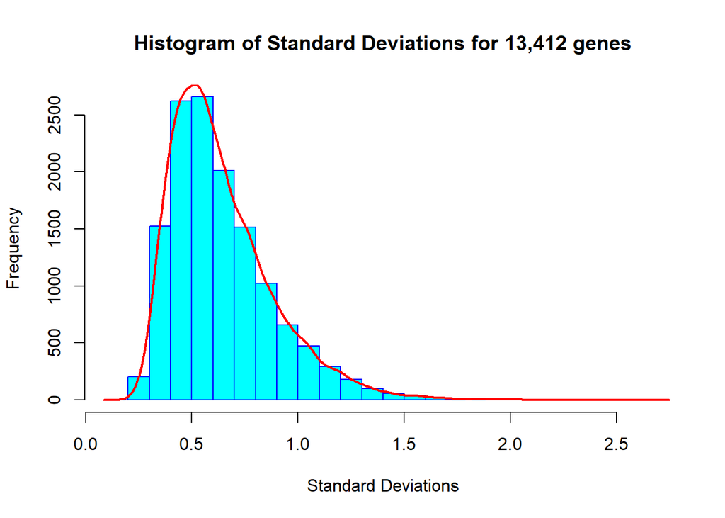

```r
hist(std,n=20, col="cyan", border="blue",
    main="Histogram of Standard Deviations for 13,412 genes",
    xlab="Standard Deviations")
dens <- density(std)
lines(dens$x, dens$y*par("usr")[4]/max(dens$y),col="red",lwd=2)
```

# Calculate and plot a proportion of genes vs. sample size graph

To get an idea of the number of genes that have an adequate sample size for confidence=95%, effect size=3 (log2 transform for the function), and power=80%

```r
# load the ssize and gdata libraries
library(gdata)
library(ssize)
```

confidence=95%, effect size=3, and power=80%

```r
fold.change <- 3.0
sig.level <- 0.05
power <- 0.8
all.size <- ssize(sd=std, delta=log2(fold.change), sig.level=sig.level, power=power)
```

Plot a proportion of genes vs. sample size graph

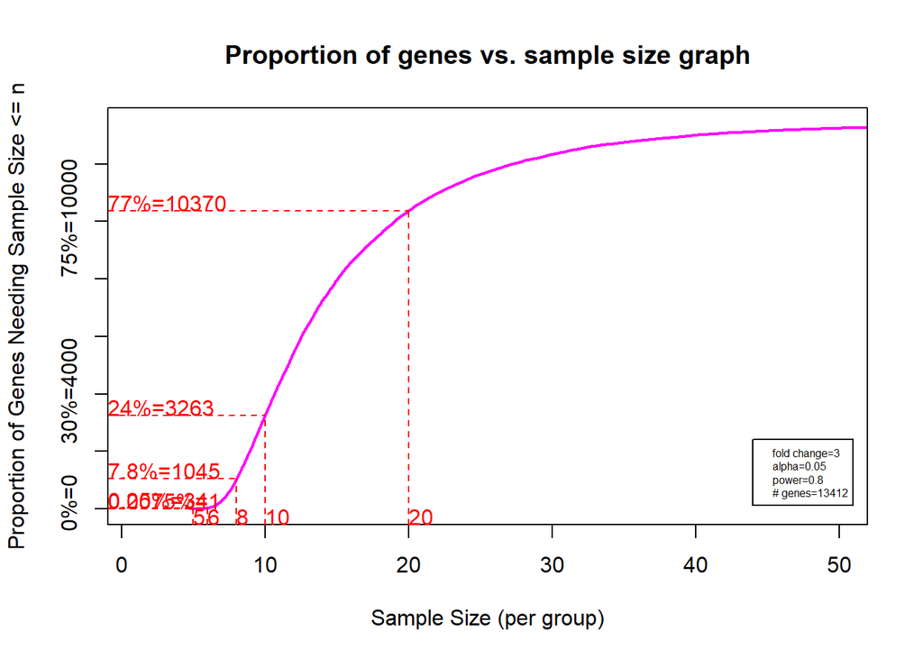

```r
ssize.plot(all.size, lwd=2, col="magenta", xlim=c(1,50))
xmax <- par("usr")[2]-1;
ymin <- par("usr")[3] + 0.05
legend(x=xmax, y=ymin,
    legend= strsplit( paste(
        "fold change=",fold.change,",",
        "alpha=", sig.level, ",",
        "power=",power,",",
        "# genes=", length(std),
        sep=''), "," )[[1]],
    xjust=1, yjust=0, cex=0.5)
title("Proportion of genes vs. sample size graph")
```

The left end of the curve is too small. Enlarge the beginning part.

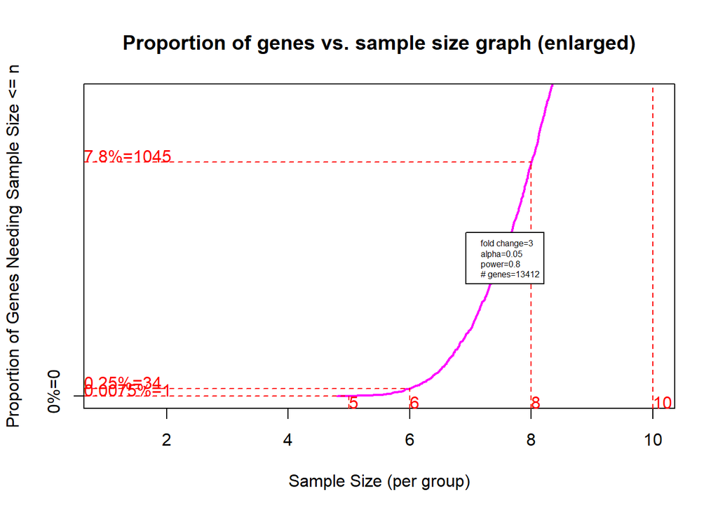

```r
ssize.plot(all.size, lwd=2, col="magenta", xlim=c(1,10), ylim=c(0,0.1))
xmax <- par("usr")[2]-1;
ymin <- par("usr")[3] + 0.05
legend(x=xmax, y=ymin,
    legend= strsplit( paste(
        "fold change=",fold.change,",",
        "alpha=", sig.level, ",",
        "power=",power,",",
        "# genes=", length(std),
        sep=''), "," )[[1]],
    xjust=1.9, yjust=0.5, cex=0.5)
title("Proportion of genes vs. sample size graph (enlarged)")
```